# Assignment 1

Following libraries are required to solve the tasks in this assignment.

```r
library(tidyverse)
library(pastecs)
```

# Task 1

In an attempt to measure the time spent by the customers in their stores, a well-known brand performed study. According to the results, the average women spends 150 minutes and walks 4.2 km when she shops, burning off around 385 calories. In contrast, men spend only about 50 minutes shopping, covering 2.4 km.

The data set looks as follows.

| sex | distance | time |
| --- | --- | --- |
| Male | 0.25 | 15 |
| Male | 0.64 | 30 |
| Male | 2.19 | 37 |
| Male | 3.20 | 65 |
| Male | 5.81 | 103 |
| Female | 2.25 | 22 |
| Female | 2.91 | 140 |
| Female | 3.15 | 160 |
| Female | 4.86 | 183 |
| Female | 7.76 | 245 |

Hint: `rep()` function saves you from writing 5 times male and 5 times female, make use of it!

```r
sex<- c(rep("Male",5),rep("Female", 5))
```

# Task 2

The gender information in the **timeData** set is currently of type “character”. Using the `mutate()` and `as_factor` functions together, code the *sex* variable as factor.

Execute `levels(timeData$sex)` to make sure that the levels are set as “Male” and “Female”.

```
## [1] "Male"   "Female"
```

# Task 3

Using the `filter` function, filter the rows having the value “Female”, and save this object as “femaleFilter”.

Hint: Following code fragment could be helpful.

```r
femaleFilter <- filter(nameOfYourDataSet,
                       columnName == "TheValueYouWanttoFilter")
```

| sex | distance | time |
| --- | --- | --- |
| Female | 2.25 | 22 |
| Female | 2.91 | 140 |
| Female | 3.15 | 160 |
| Female | 4.86 | 183 |
| Female | 7.76 | 245 |

# Task 4

Using the `ggplot` function, create a boxplot using the `timeData` data. Set the aesthetics argument as `aes(sex, distance, fill = sex))`. You can design your own boxplot, or try to replicate the following result.

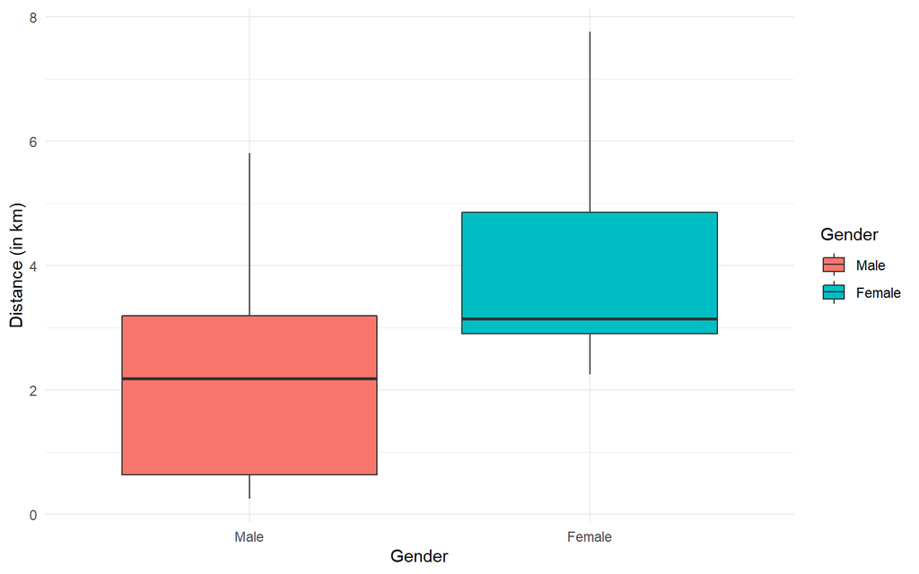

# Task 5

We are going to investigate the `Lecturer Data.csv` we have created in Lecture 1. First, import the data in your R environment using the following code.

```r
lecturerData<-read.csv("Lecturer Data.csv", header = TRUE)
```

| name | birth_date | job | friends | alcohol | income | neurotic |
| --- | --- | --- | --- | --- | --- | --- |
| Ben | 1977-07-03 | Lecturer | 5 | 10 | 20000 | 10 |
| Martin | 1969-05-24 | Lecturer | 2 | 15 | 40000 | 17 |
| Andy | 1973-06-21 | Lecturer | 0 | 20 | 35000 | 14 |
| Paul | 1970-07-16 | Lecturer | 4 | 5 | 22000 | 13 |
| Graham | 1949-10-10 | Lecturer | 1 | 30 | 50000 | 21 |
| Carina | 1983-11-05 | Student | 10 | 25 | 5000 | 7 |
| Karina | 1987-10-08 | Student | 12 | 20 | 100 | 13 |
| Doug | 1989-09-16 | Student | 15 | 16 | 3000 | 9 |
| Mark | 1973-05-20 | Student | 12 | 17 | 10000 | 14 |
| Zoe | 1984-11-12 | Student | 17 | 18 | 10 | 13 |

Below is the code which creates a scatterplot printing the alcohol consumption (x axis) and neuroticism levels (y axis), using the theme minimal.

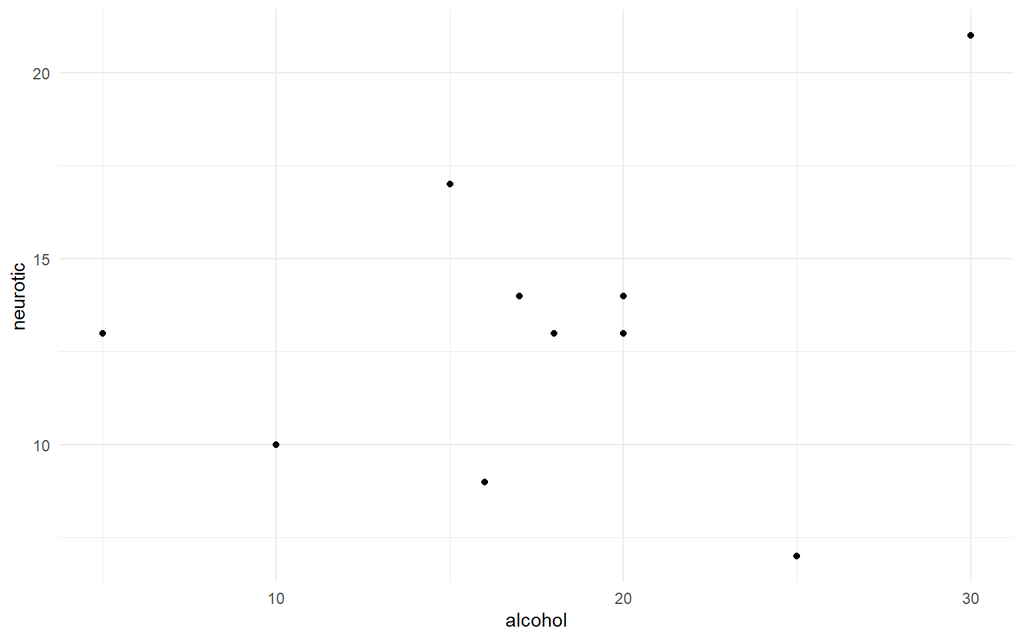

```r
ggplot(lecturerData, aes(alcohol, neurotic)) +
  geom_point()+
  theme_minimal()
```

Use the `colour` argument in the `aes()` function to differentiate between the students and lecturers. The results might look like the following graph.

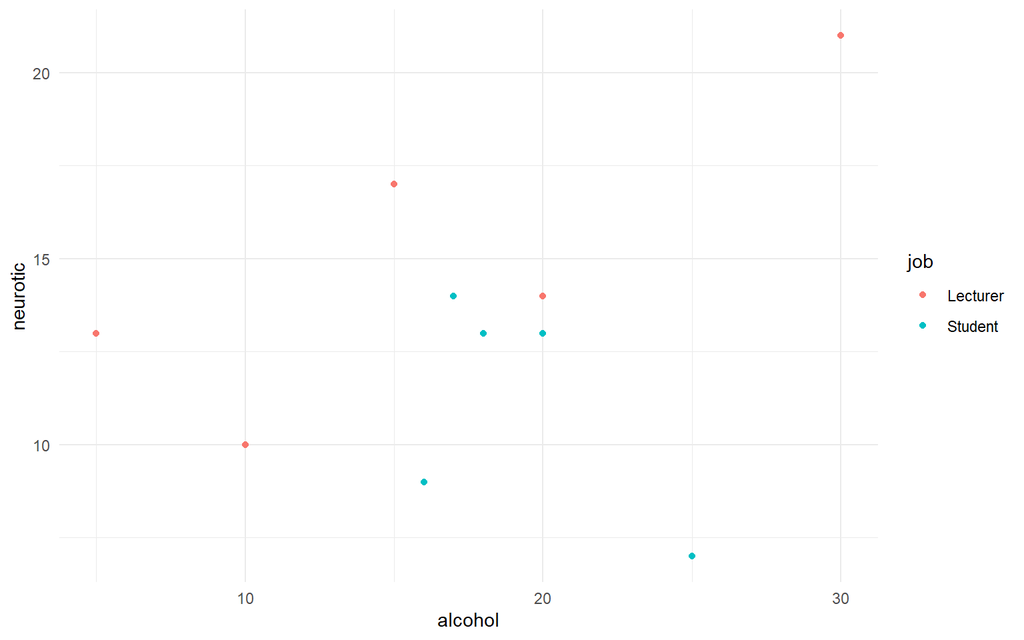

In the final step, add the lines summarizing the trends in the two groups, using the `geom_smooth()` function.

Hint: Use the following code fragment between `geom_point()` and `theme_minimal()`.

```r
geom_smooth(method = "lm", alpha = 0.1) +
  labs(x = "Alcohol consumption per week (units)",
       y = "Neuroticism",
       colour = "Job") +
```

The final result of this task might look similar to the graph below.

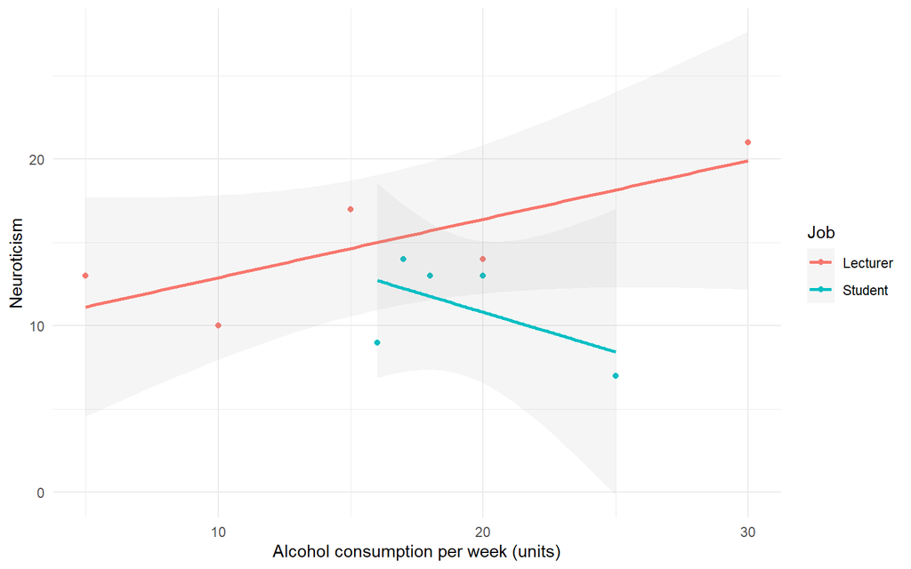